# Assignment4

2025-02-28

# Exploratory Analysis & Initial Setup (Some Headers Don’t Work)

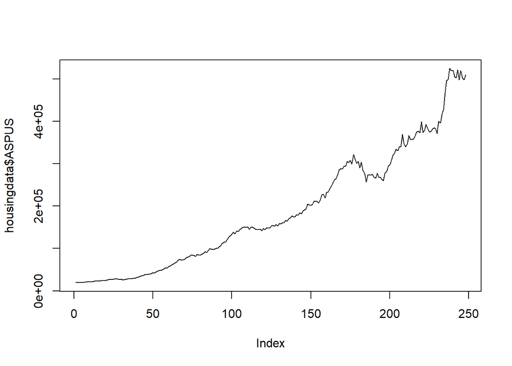

```
## integer(0)
```

```r
library(ggplot2)
library(fpp)
library(fpp2)
library(TTR)

# Getting the CSV into usable data
housingdata <- read.csv("C:/Users/woodb/OneDrive/Documents/College Files/Spring 25/Time Series Models For Business/ASPUS/Average Sales Price of Houses Sold for the US.csv", sep = ",", header = 1)

# Converting the data into a time series for when we need it
housingseries <- ts(housingdata$ASPUS,start=c(1963,1),end=c(2024,4), frequency=4)

# Basic plot of the time series
plot(housingdata$ASPUS, col="white") + lines(housingdata$ASPUS, col="black")
```

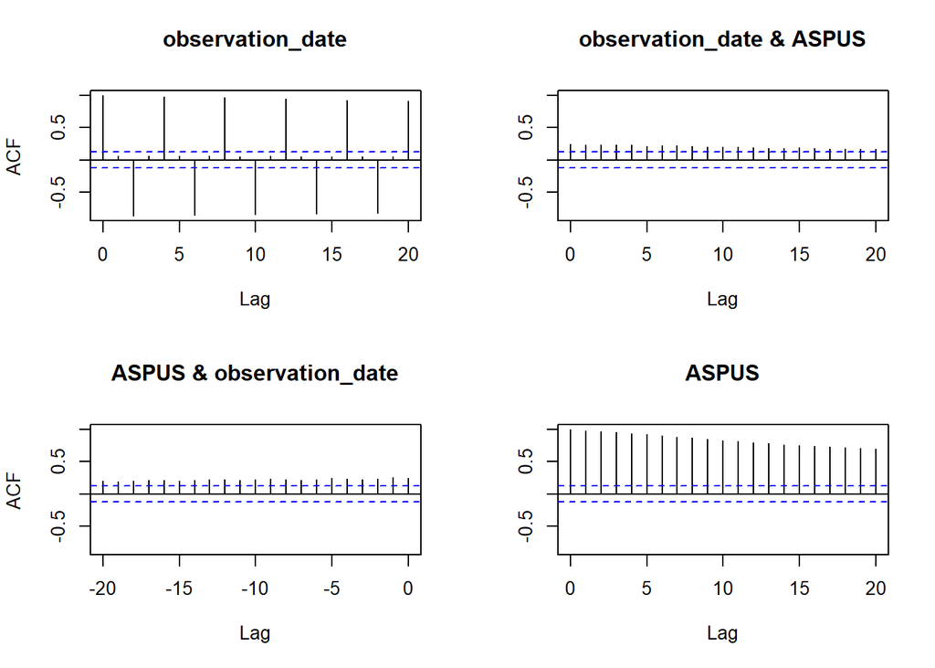

```r
# Auto-correlation, shows that the date and price aren't super highly correlated but are still relevant enough (ASPUS & Observation date is slightly higher than observation date & ASPUS)
acf(housingdata)
```

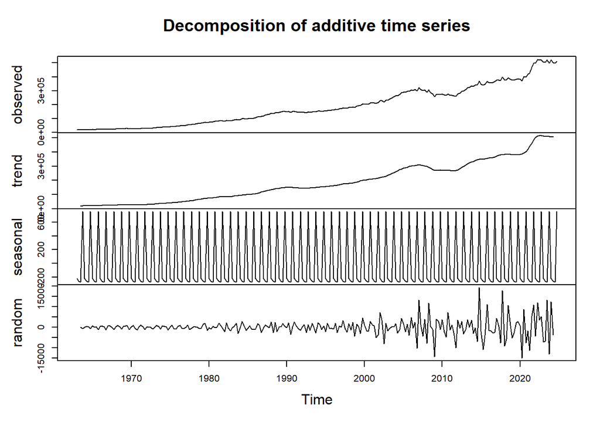

```r
# Decomposition shows that the data gets a little wonky at around 2000, but starts to get really crazy at around 2008: This definitely has something to do with the housing crisis & real estate bubble popping around that time. It's a little surprising that it hasn't managed to recover since then, though.
housingdecomp <- decompose(housingseries)
plot(housingdecomp)
```

Running Models

```r
library(ggplot2)
library(fpp)
library(fpp2)
library(TTR)
# Getting the CSV into usable data
housingdata <- read.csv("C:/Users/woodb/OneDrive/Documents/College Files/Spring 25/Time Series Models For Business/ASPUS/Average Sales Price of Houses Sold for the US.csv", sep = ",", header = 1)

# Converting the data into a time series for when we need it
housingseries <- ts(housingdata$ASPUS,start=c(1963,1),end=c(2024,4), frequency=4)


meanf(housingseries,5)
```

```
##         Point Forecast    Lo 80    Hi 80     Lo 95  Hi 95
## 2025 Q1       187350.4 7166.586 367534.2 -88833.18 463534
## 2025 Q2       187350.4 7166.586 367534.2 -88833.18 463534
## 2025 Q3       187350.4 7166.586 367534.2 -88833.18 463534
## 2025 Q4       187350.4 7166.586 367534.2 -88833.18 463534
## 2026 Q1       187350.4 7166.586 367534.2 -88833.18 463534
```

```r
naive(housingseries,5)
```

```
##         Point Forecast    Lo 80    Hi 80    Lo 95    Hi 95
## 2025 Q1         510300 499825.6 520774.4 494280.8 526319.2
## 2025 Q2         510300 495487.0 525113.0 487645.4 532954.6
## 2025 Q3         510300 492157.8 528442.2 482553.9 538046.1
## 2025 Q4         510300 489351.2 531248.8 478261.6 542338.4
## 2026 Q1         510300 486878.5 533721.5 474479.9 546120.1
```

```r
snaive(housingseries,5)
```

```
##         Point Forecast    Lo 80    Hi 80  Lo 95  Hi 95
## 2025 Q1         519700 497199.2 542200.8 485288 554112
## 2025 Q2         502200 479699.2 524700.8 467788 536612
## 2025 Q3         498700 476199.2 521200.8 464288 533112
## 2025 Q4         510300 487799.2 532800.8 475888 544712
## 2026 Q1         519700 487879.0 551521.0 471034 568366
```

```r
rwf(housingseries,5)
```

```
##         Point Forecast    Lo 80    Hi 80    Lo 95    Hi 95
## 2025 Q1         510300 499825.6 520774.4 494280.8 526319.2
## 2025 Q2         510300 495487.0 525113.0 487645.4 532954.6
## 2025 Q3         510300 492157.8 528442.2 482553.9 538046.1
## 2025 Q4         510300 489351.2 531248.8 478261.6 542338.4
## 2026 Q1         510300 486878.5 533721.5 474479.9 546120.1
```

```r
rwf(housingseries,5,drift=TRUE)
```

```
##         Point Forecast    Lo 80    Hi 80    Lo 95    Hi 95
## 2025 Q1       512287.9 502086.8 522489.0 496686.6 527889.1
## 2025 Q2       514275.7 499820.1 528731.3 492167.8 536383.6
## 2025 Q3       516263.6 498523.6 534003.5 489132.7 543394.4
## 2025 Q4       518251.4 497726.2 538776.6 486860.8 549642.0
## 2026 Q1       520239.3 497245.7 543232.8 485073.6 555404.9
```

```r
ma(housingseries,order=9)
```

```
##           Qtr1      Qtr2      Qtr3      Qtr4
## 1963        NA        NA        NA        NA
## 1964  20022.22  20211.11  20455.56  20733.33
## 1965  21077.78  21477.78  21788.89  22044.44
## 1966  22388.89  22688.89  23011.11  23322.22
## 1967  23733.33  24177.78  24555.56  25000.00
## 1968  25533.33  25988.89  26422.22  26777.78
## 1969  27066.67  27277.78  27200.00  27166.67
## 1970  27200.00  27311.11  27333.33  27344.44
## 1971  27555.56  27822.22  28155.56  28777.78
## 1972  29500.00  30366.67  31177.78  32100.00
## 1973  33188.89  34255.56  35322.22  36322.22
## 1974  37355.56  38444.44  39233.33  40177.78
## 1975  41222.22  42311.11  43366.67  44622.22
## 1976  45988.89  47477.78  48744.44  50444.44
```

[output cut: 48 more lines]

```r
HoltWinters(housingseries)
```

```
## Holt-Winters exponential smoothing with trend and additive seasonal component.
##
## Call:
## HoltWinters(x = housingseries)
##
## Smoothing parameters:
##  alpha: 0.8574921
##  beta : 0.0210951
##  gamma: 0.04238696
##
## Coefficients:
##           [,1]
## a  508703.5357
## b    3348.3926
## s1   -105.2908
## s2    244.3179
## s3    203.2449
## s4    694.4708
```

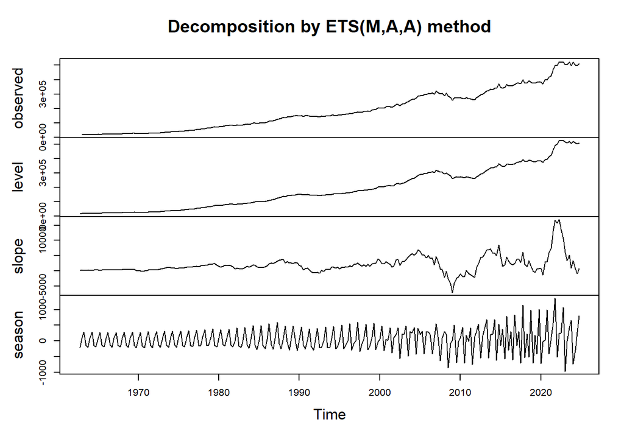

```r
plot(ets(housingseries))
```

Model Explanation  
The MeanF model was absolutely abyssmal because it took into account the older data just as much as the newest data, skewing it massively. I fully expect this to be the least accurate model.

The Naive model is fairly accurate, all things considered, though the exact accuracy can only really be determined after the data point comes in. I have more faith in the seasonal naive model, because it uses a little more calculation than the normal naive model.

The random-walk-drift model is decent, but not acceptable. The random walk with drift isn’t much better, so I don’t think I’d be wanting to use these models of prediction for anything serious. The fact that Seasonal Naive forecasting is about even with it is astounding.

The moving average has fairly minimal residuals and seems to be generally accurate. If the market remains stable, moving average with a window of 9 seems very accurate for predicting how much a home will cost.

Holt-Winters is probably not a very good pick for a series of data like this due to the rapid change in the nature of the data, though it always does look very nice on a graph. I’d probably use this as a companion to the moving average 9 model.

The decomposition here specifically shows the slope as its own graph which is very helpful as it shows spikes of growth or decline relative to the data itself. It’s very interesting to see the slope decrease in 2008 and spike up like crazy in 2020. Looking at the trend of the slope, though, it means that the market’ll probably be relatively stable for the foreseeable future.